# Lab 9: Arranging plots and telling a story

Elijah Russell

12/18/25

In this lab, we will recreate [Figure 29.12](https://clauswilke.com/dataviz/telling-a-story.html#fig:tech-stocks-repetitive) from Wilke’s Data Visualization textbook. *Be sure to click this link and reference it as you work through the lab*

## Load data and libraries

```r
tech_stocks <- read_csv("https://wilkelab.org/SDS375/datasets/tech_stocks.csv")
```

### Print out five randomly selected rows

```r
tech_stocks %>%
  slice_sample(n=5)
```

```
## # A tibble: 5 × 6
##   company   ticker date       price index_price price_indexed
##   <chr>     <chr>  <date>     <dbl>       <dbl>         <dbl>
## 1 Apple     AAPL   2008-02-13  18.5        80.1          23.1
## 2 Apple     AAPL   2009-12-30  30.2        80.1          37.7
## 3 Alphabet  GOOG   2013-08-14 434.        285.          152.
## 4 Apple     AAPL   2016-09-30 113.         80.1         141.
## 5 Microsoft MSFT   2011-11-11  26.9        28.4          94.6
```

## Make a plot of all companies’ stock prices over time

Use the `price_indexed` variable.

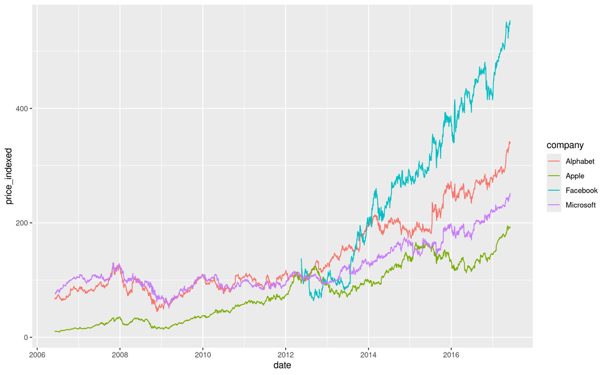

```r
ggplot(tech_stocks, aes(x=date,y=price_indexed, color = company)) +
  geom_line()
```

## Facebook only

Now we’ll work on recreating the story of Facebook’s rapid growth over other comparator tech stocks. First, plot only Facebook’s stock price over time and *pick a color* of your choosing.

Use the following arguments to the `theme` function to match the version in Wilke’s Figure 29.12 (for simplicity, don’t worry about recreating the secondary axis trick here):

```r
  theme_minimal() +
  theme( legend.position = "none",
         text = element_text(size = 20),
         panel.grid.major.x = element_blank(),
         panel.grid.minor.x = element_blank() )
```

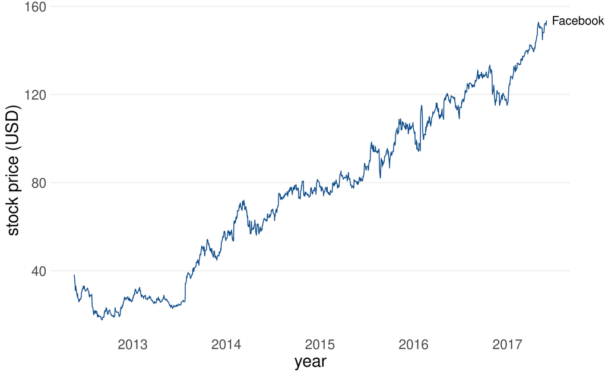

```r
tech_stocks %>%
  filter(company == "Facebook") %>%
  ggplot(aes(x=date, y=price)) +
  geom_line(color = "dodgerblue4") +
  geom_text(
    data = tech_stocks %>%
      filter(company == "Facebook") %>%
      slice_max(date, n = 1),
    aes(label = company),
    size = 5,
    hjust = -0.1,
    show.legend = FALSE
  ) +
  theme_minimal() +
  theme( legend.position = "none",
         text = element_text(size = 20),
         panel.grid.major.x = element_blank(),
         panel.grid.minor.x = element_blank(),
         panel.grid.minor.y = element_blank()) +
  labs(x="year", y="stock price (USD)") +
  coord_cartesian(clip = "off") +
  theme(plot.margin = margin(6.5, 45, 6.5, 6.5))
```

Save this plot as an object, e.g. `plot_fb <- ggplot( ...`.

```r
plot_fb <- tech_stocks %>%
  filter(company == "Facebook") %>%
  ggplot(aes(x=date, y=price)) +
  geom_line(color = "dodgerblue4") +
  geom_text(
    data = tech_stocks %>%
      filter(company == "Facebook") %>%
      slice_max(date, n = 1),
    aes(label = company),
    size = 5,
    hjust = -0.1,
    show.legend = FALSE
  ) +
  theme_minimal() +
  theme( legend.position = "none",
         text = element_text(size = 20),
         panel.grid.major.x = element_blank(),
         panel.grid.minor.x = element_blank(),
         panel.grid.minor.y = element_blank()) +
  labs(x="year", y="stock price (USD)") +
  coord_cartesian(clip = "off") +
  theme(plot.margin = margin(6.5, 45, 6.5, 6.5))
```

## Percent growth

The code below calculates the percent growth for each stock since Facebook’s stock first went public.

```r
final_prices <- filter(tech_stocks, date == ymd("2017-05-31"))

perc_increase <- final_prices %>%
  mutate(
    perc = 100*(price-index_price)/index_price,
    perc_label = paste0(round(perc), "%") ) %>%
  arrange(perc)
```

Use the `perc_increase` dataset to create a barplot. As in [Figure 29.12](https://clauswilke.com/dataviz/telling-a-story.html#fig:tech-stocks-repetitive), - use a color scheme that highlights Facebook’s bar - use `geom_text` to label the actual percentage for each company (*Hint*: add a `position = position_nudge( x = -1)` argument and play around with the nudge amount), - order the companies by their percent growth (*Hint*: see Lecture 8), and - copy/edit the theme settings from our last plot to match Figure 29.12’s bar plot.

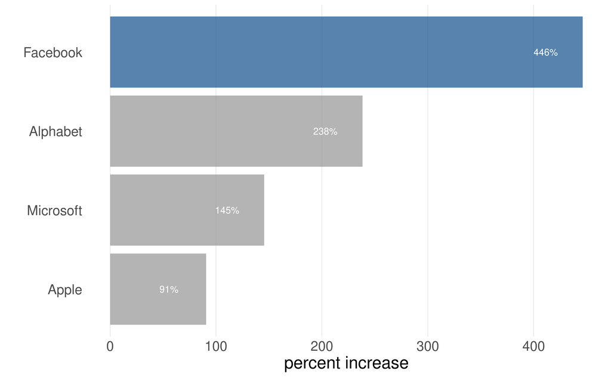

```r
ggplot(perc_increase, aes(x=perc, y=reorder(company, perc), fill=company)) +
  geom_col(alpha=0.7) +
  scale_fill_manual(values=c(Microsoft="grey58", Apple="grey58", Alphabet="grey58", Facebook="dodgerblue4")) +
  theme_minimal() +
  geom_text(aes(label=perc_label),
            color="white",
            position = position_nudge(x=-35)) +
  theme( legend.position = "none",
         text = element_text(size = 20),
         panel.grid.major.y = element_blank(),
         panel.grid.minor.y = element_blank(),
         panel.grid.minor.x = element_blank()) +
  labs(x="percent increase", y="")
```

Save your barplot as an object.

```r
plot_bar <- ggplot(perc_increase, aes(x=perc, y=reorder(company, perc), fill=company)) +
  geom_col(alpha=0.7) +
  scale_fill_manual(values=c(Microsoft="grey58", Apple="grey58", Alphabet="grey58", Facebook="dodgerblue4")) +
  theme_minimal() +
  geom_text(aes(label=perc_label),
            color="white",
            position = position_nudge(x=-35)) +
  theme( legend.position = "none",
         text = element_text(size = 20),
         panel.grid.major.y = element_blank(),
         panel.grid.minor.y = element_blank(),
         panel.grid.minor.x = element_blank()) +
  labs(x="percent increase", y="")
```

## Combine the plots and adjust chunk options

Use the `plot_grid` function from `cowplot` to combine your figures and add labels. (Aside: see [more vignettes/tutorials](https://wilkelab.org/cowplot/articles/index.html) for other ways `cowplot` can help you combine multiple plots, including adding a logo or watermark, and advanced configurations).

### Export your plot

Use the `ggsave` function to create a `.png` image file of your combined plot. You’ll save the output from our combining function as an object, and then feed that to `ggsave`. The help file for `ggsave` contains many other useful options, including changing the file type (e.g., .pdf, .jpeg, etc.), dimensions, and resolution.

```r
both_plots_cowplot <- plot_grid(plot_fb, plot_bar,
           ncol = 1,
           labels = c('a', 'b'),
           label_size = 12 )
```

```r
ggsave( "FB_growth.png",
        both_plots_cowplot,
        width = 10, height = 10, units = "in", dpi = 300 )
```

After you run this chunk, check to see that your file shows up in the bottom right window of RStudio.

## Inserting images into an Rmd

We can insert images into our knitted .Rmd file just like code chunks, but the syntax is different:

[figure not shown]

Figure 1: Facebook logo (This is a caption)

We may also want to add an image directly on our plot, as below. I’ve copy/pasted this code from the cowplot tutorial which uses a different image file. **Play with the arguments so that the logo shows up nicely on our plot.** Adjust the `x, y` positions (per `draw_image`’s help file, these coordinates run from 0 to 1 with the point (0,0) being the lower left corner) and decrease the `width` and `height` arguments.

Use `cowplot`’s `plot_grid` function to **create a combined plot that includes the logo image, and at least one of the plots you created above**. Use the `rel_widths` or `rel_heights` argument to adjust relative width or heights of each plot. It’s ok if it looks a bit silly for this assignment; hopefully you can imagine how this could be potentially useful in your final project.

[figure not shown]

```r
logo_file <- "facebook_logo.png"

ggdraw(both_plots_cowplot) +
  draw_image(logo_file,
             x = 1, y = 0.15,
             hjust = 1, vjust = 1,
             width = 0.1, height = 0.1)
```